# Introduction to R: Session 3

Eleonora Minaeva, eleonora.minaeva@eui.eu

2023-09-30

[figure not shown]

## Why visualize?

1. **Explore and understand data** — visualizing data helps us analyze and interpret processes, like identifying sudden trends. Even basic trend analysis can benefit from visual charts, providing stronger conclusions and supporting arguments.
2. **Spot trends and detect mistakes** — visual analysis makes it easier to identify patterns and errors in data that might be challenging to spot using only data tables. For instance, you can quickly notice data gaps or response patterns in surveys.
3. **Share insights visually** — use visual representations, like infographics and data storytelling, to present research findings or explain complex phenomena in an easily understandable way to others.

## Some useful sources

- The R Graph Gallery: https://r-graph-gallery.com/
- step-by-step tutorial on improving the plot in ggplot2 from Cedric Scherer: https://www.cedricscherer.com/2019/05/17/the-evolution-of-a-ggplot-ep.-1/
- dataviz inspiration: https://www.dataviz-inspiration.com/
- palettes guidebook: https://wilkelab.org/SDS375/slides/color-scales.html#17
- color schemes: https://colorbrewer2.org/#type=sequential&scheme=BuGn&n=3
- ggthemes package: https://github.com/jrnold/ggthemes
- urbnthemes package: https://urbaninstitute.github.io/urbnthemes/index.html
- hrbrthemes package: https://github.com/hrbrmstr/hrbrthemes
- bbplot package: https://github.com/bbc/bbplot/
- xkcd package: https://xkcd.r-forge.r-project.org/

## Packages

```r
pacman::p_load(
  tidyverse,
  ggplot2,
  ggthemes,
  hrbrthemes,
  viridis)
```

```r
# upload 'vdem_coup' data if you don't have it in your global environment space

vdem_coup <- readxl::read_excel("C:/Program Files/GitHub/IntroR/Session2/vdem_coup.xlsx")
```

## Ggplot2: advantages and disadvantages

1. Grammar of Graphics: ggplot2 follows a structured approach, making complex plots more understandable.
2. Customizable: Offers extensive plot customization options.
3. Layered Approach: Easily build complex plots with multiple datasets.
4. Wide Data Support: Suitable for various data types.

**BUT**

1. Learning Curve: Steep learning curve, especially for newcomers to R and data visualization.
2. Code Length: Creating complex visualizations can result in verbose code.
3. Advanced Customization: Highly specialized customizations may require in-depth knowledge of ggplot2’s inner workings.

## Ggplot2 syntax

1. **Data Mapping (aes)**:
   - Start by specifying the data frame you want to use.
   - Use the **`aes()`** function to map variables in your data frame to aesthetics (visual properties) of your plot, such as x-axis, y-axis, color, size, shape, etc.
   - For example, **`aes(x = variable1, y = variable2, color = variable3)`** maps variables to the x-axis, y-axis, and color aesthetic.
2. **Geometric Objects (geom)**:
   - Use geometric functions (geoms) to represent data points in your plot. Geoms define how data should be displayed.
   - Common geoms include **`geom_point()`**, **`geom_line()`**, **`geom_bar()`**, **`geom_histogram()`**, and many others.

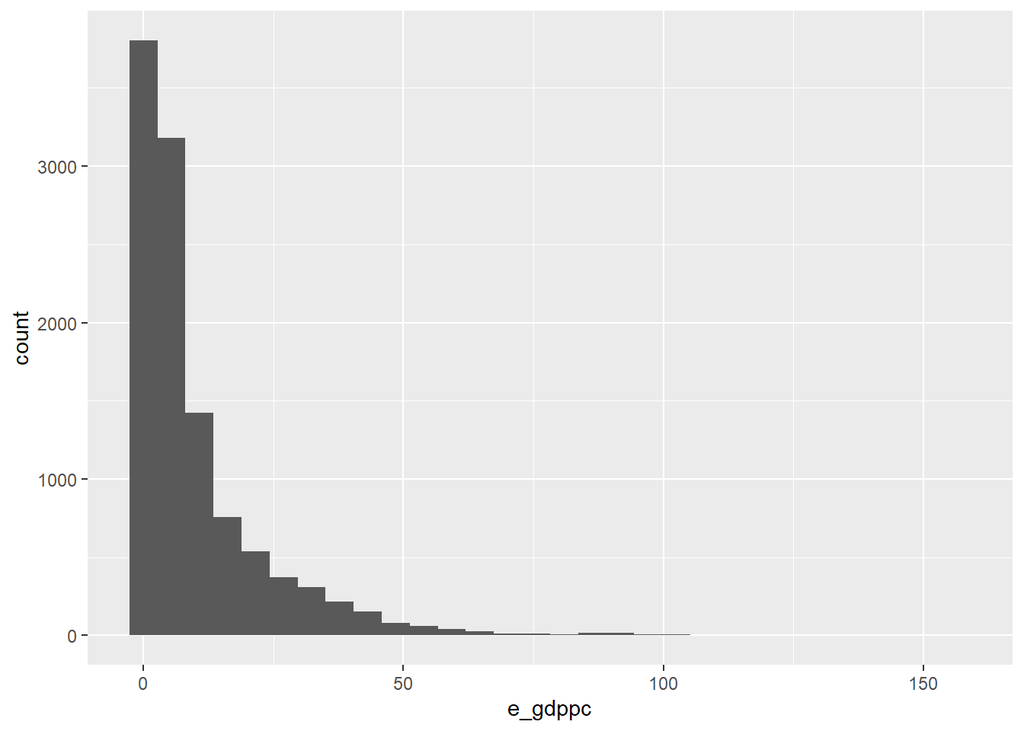

```r
# histogram
ggplot(vdem_coup, aes(x=e_gdppc)) +
      geom_histogram()
```

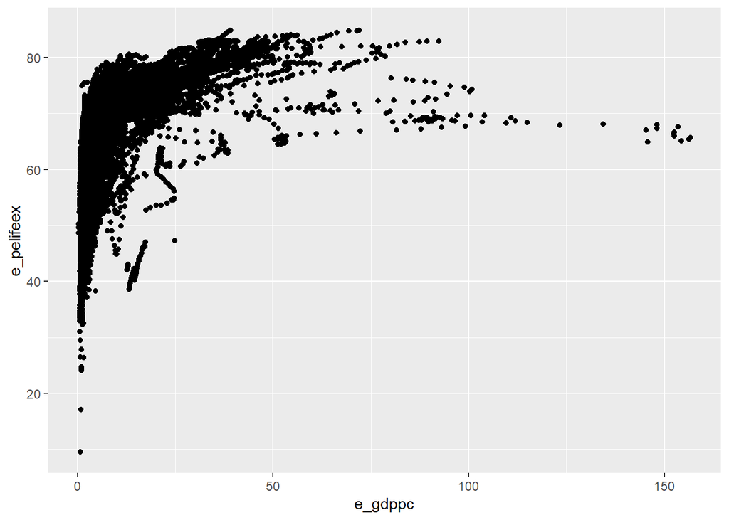

```r
# scatterplot
ggplot(vdem_coup, aes(x=e_gdppc, y=e_pelifeex)) +
        geom_point()
```

#### Small exercise: how should these variables be transformed?

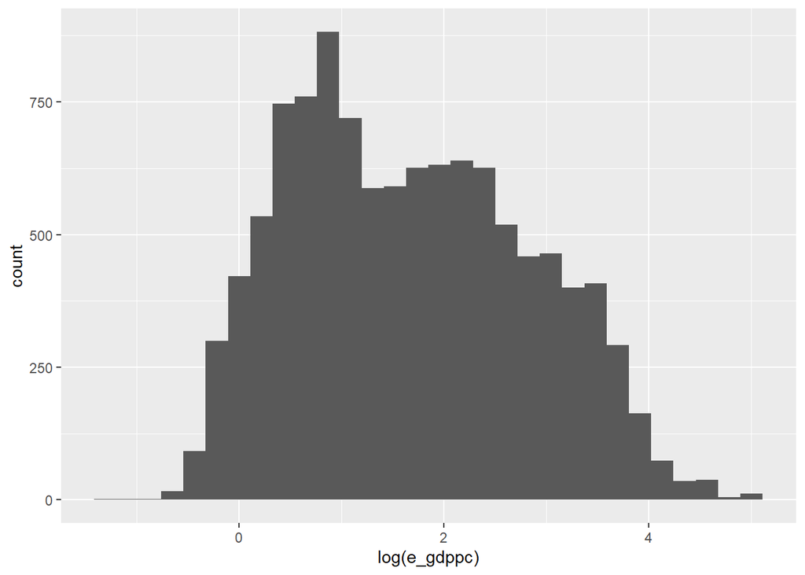

```r
# histogram
ggplot(vdem_coup, aes(x=log(e_gdppc))) +
      geom_histogram()
```

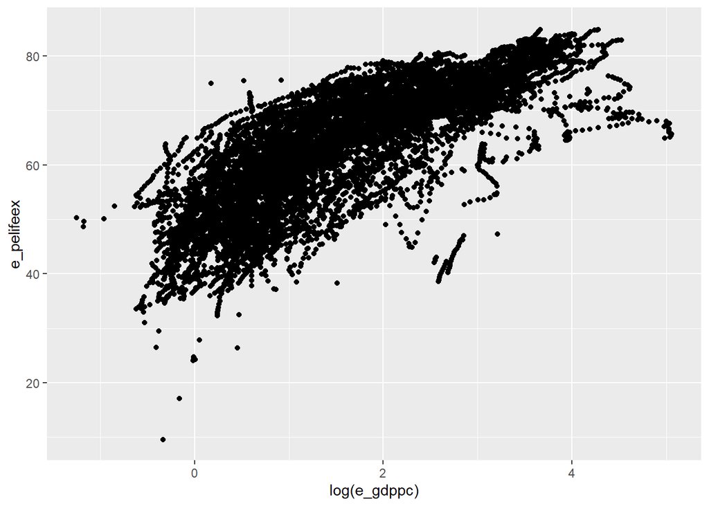

```r
# scatterplot
ggplot(vdem_coup, aes(x=log(e_gdppc), y=e_pelifeex)) +
        geom_point()
```

3. **Layers**:
   - Build your plot by adding layers, one on top of the other. Each layer can represent different aspects of the data.
   - For example, you can add points, lines, and text to the same plot by stacking layers.

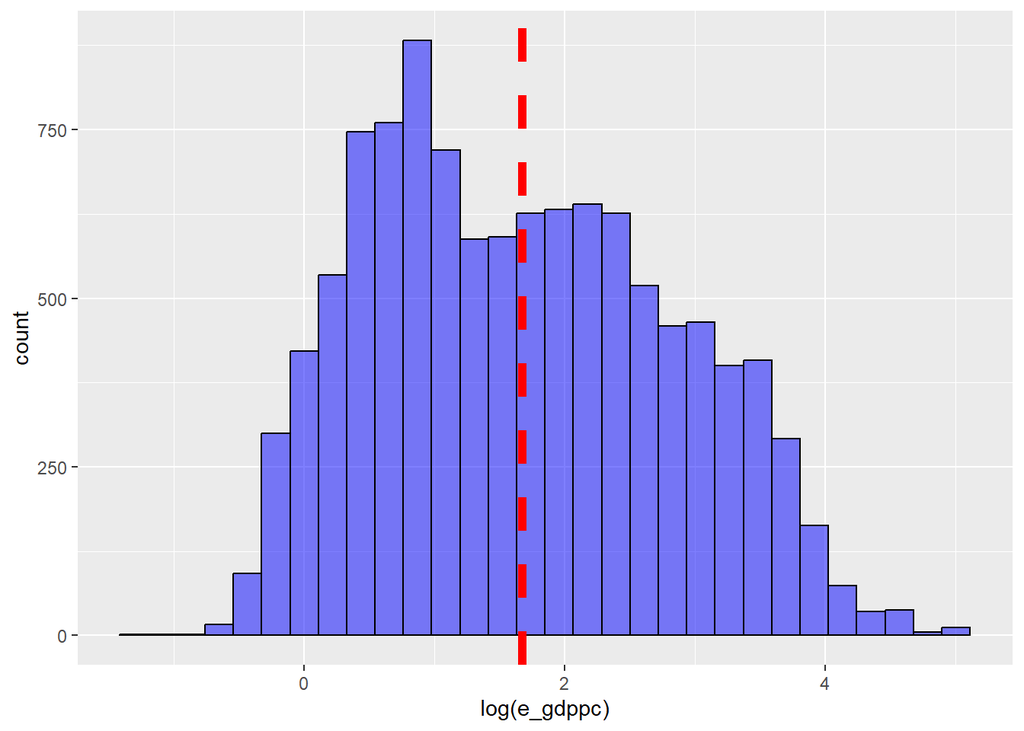

```r
# histogram: adding mean line
    ggplot(vdem_coup, aes(x = log(e_gdppc))) +
      geom_histogram(alpha = 0.5, fill = "blue", color = "black") +  # Adjust alpha value (0.5 makes it 50% transparent)
      geom_vline(xintercept = mean(log(vdem_coup$e_gdppc), na.rm = TRUE), color = "red", linetype = "dashed", size = 2)
```

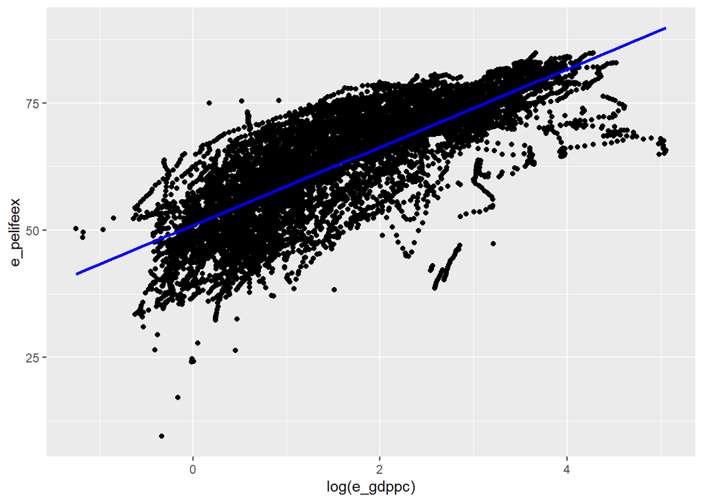

```r
# scatterplot: adding lm line
    ggplot(vdem_coup, aes(x = log(e_gdppc), y = e_pelifeex)) +
      geom_point(linewidth = 0.5) + # size in the previous versions of ggplot2
      stat_smooth(method = lm, se = FALSE, color = "blue")
```

#### Exercise: build a scatter plot of the relations between natural resources revenue pc and life expectancy

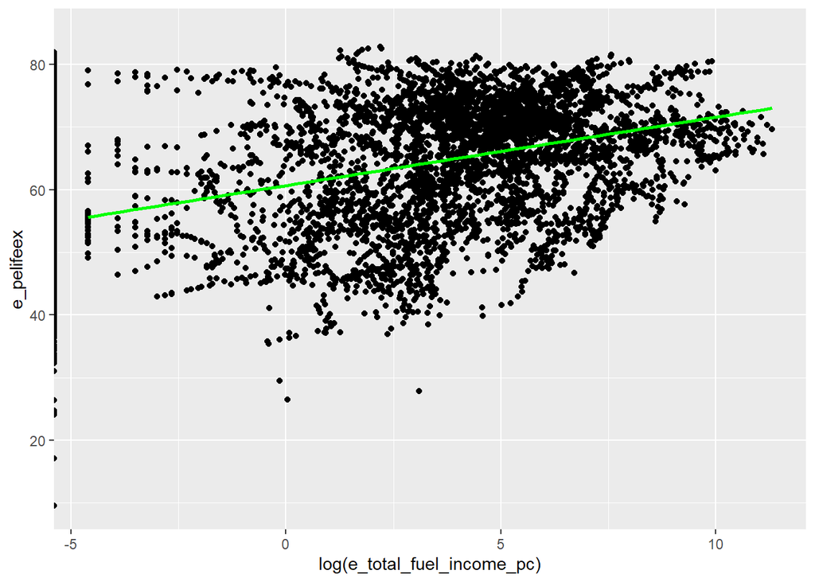

```r
ggplot(vdem_coup, aes(x = log(e_total_fuel_income_pc), y = e_pelifeex)) +
      geom_point(linewidth = 0.5) +
      stat_smooth(method = lm, se = FALSE, color = "green")
```

4. **Labels and Titles**:
   - Add titles and labels to your plot using functions like **`labs()`** to specify titles, axis labels, and other text elements.

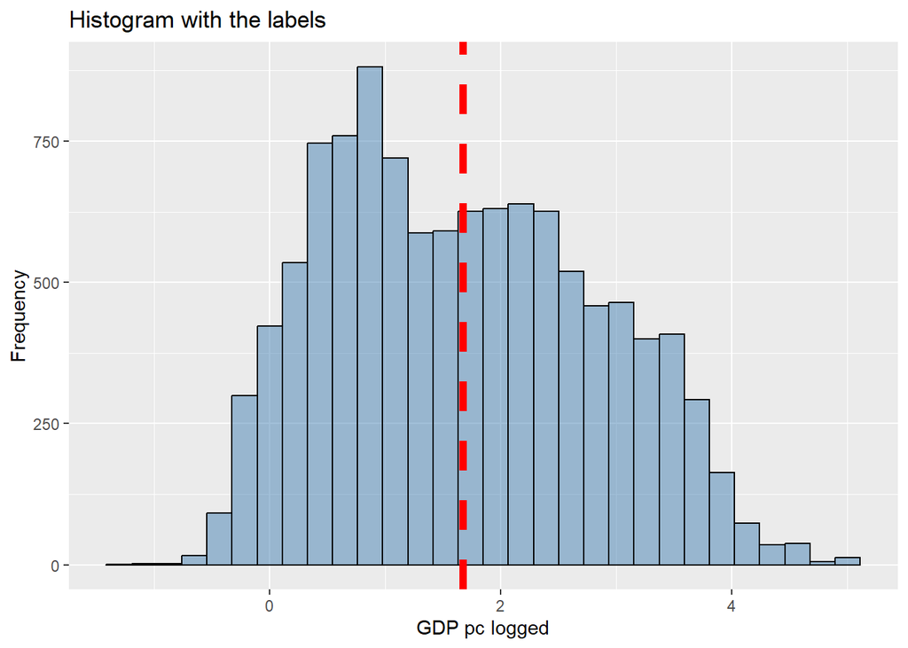

```r
ggplot(vdem_coup, aes(x = log(e_gdppc))) +
      geom_histogram(alpha = 0.5, fill = "steelblue", color = "black") +
      geom_vline(xintercept = mean(log(vdem_coup$e_gdppc), na.rm = TRUE), color = "red", linetype = "dashed", size = 2)+
      labs(title = "Histogram with the labels",
           x = "GDP pc logged",
           y = "Frequency")
```

5. **Themes**:
   - Customize the appearance of your plot using themes. Themes control aspects like fonts, colors, grid lines, and background.
   - Apply themes using the **`theme()`** function.

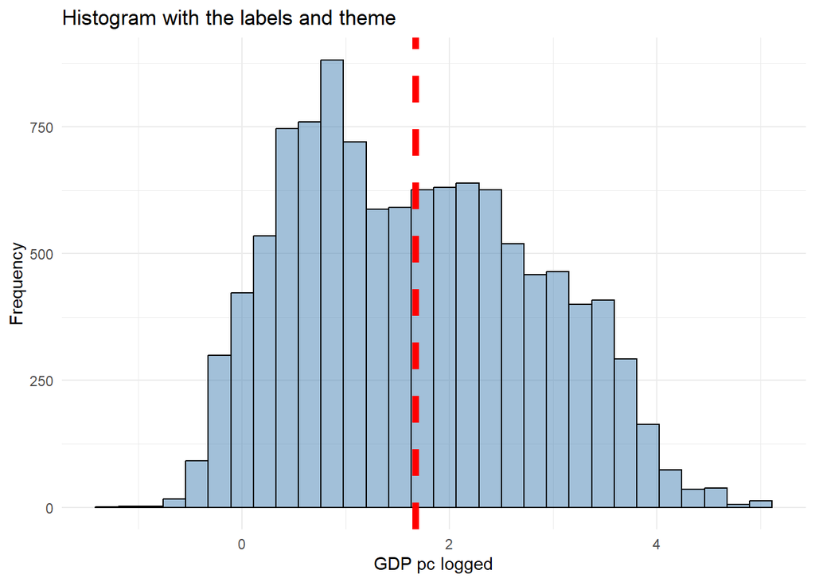

[output not shown]

```r
ggplot(vdem_coup, aes(x = log(e_gdppc))) +
      geom_histogram(alpha = 0.5, fill = "steelblue", color = "black") +
      geom_vline(xintercept = mean(log(vdem_coup$e_gdppc), na.rm = TRUE), color = "red", linetype = "dashed", size = 2) +
      labs(title = "Histogram with the labels and theme",
           x = "GDP pc logged",
           y = "Frequency") +
      theme_minimal()
```

6. **Data transformation: dplyr + ggplot2**
   - Apply data transformations before plotting.

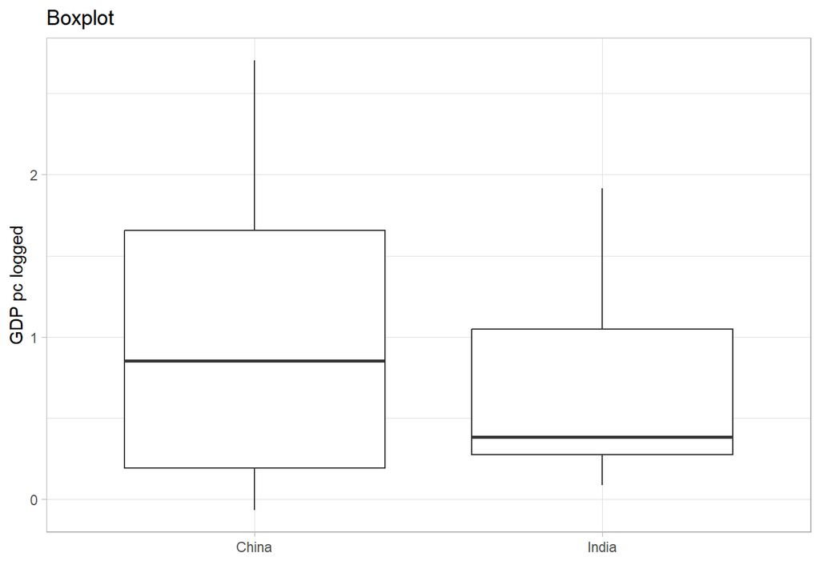

```r
# boxplot
vdem_coup %>%
      filter(country_name == c("China", "India")) %>%
      ggplot(aes(x = as.factor(country_name), y = log(e_gdppc))) +
      geom_boxplot()+
      labs(title = "Boxplot",
           x = "",
           y = "GDP pc logged") +
      theme_light()
```

#### *Exercise 1:*

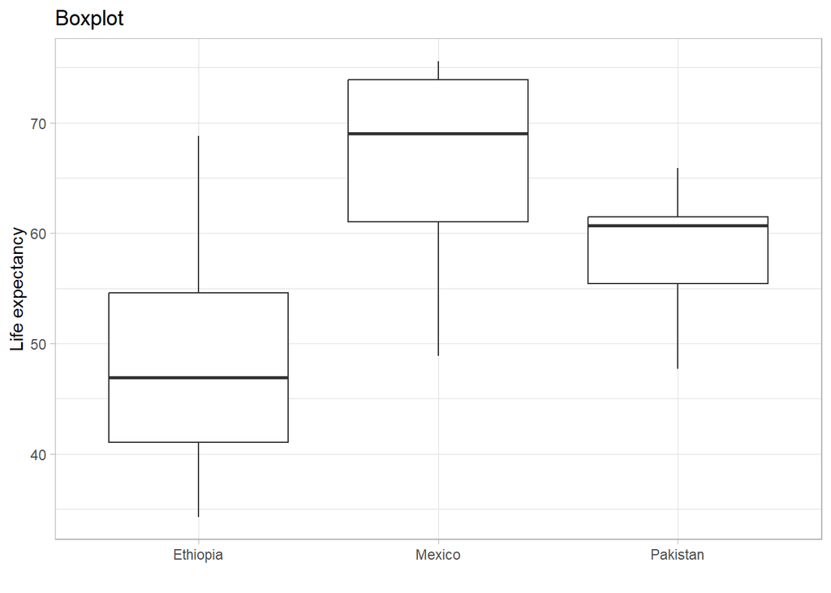

```r
vdem_coup %>%
      filter(country_name == c("Mexico", "Ethiopia", "Pakistan")) %>%
      ggplot(aes(x = as.factor(country_name), y = e_pelifeex)) +
      geom_boxplot()+
      labs(title = "Boxplot",
           x = "",
           y = "Life expectancy") +
      theme_light()
```

#### *Exercise 2:*

- filter NAs, ‘-88’, ‘-77’, and ‘-66’ by ‘e_p_polity’ variable
- create a new variable - ‘Regime’ where ‘Democratic’ values vary from 6 to 10 including, ‘Autocratic’ – from -10 to 5 (variable e_p_polity)
- create two boxplots showing the variability of the variable log(e_gdppc) across these two regime types

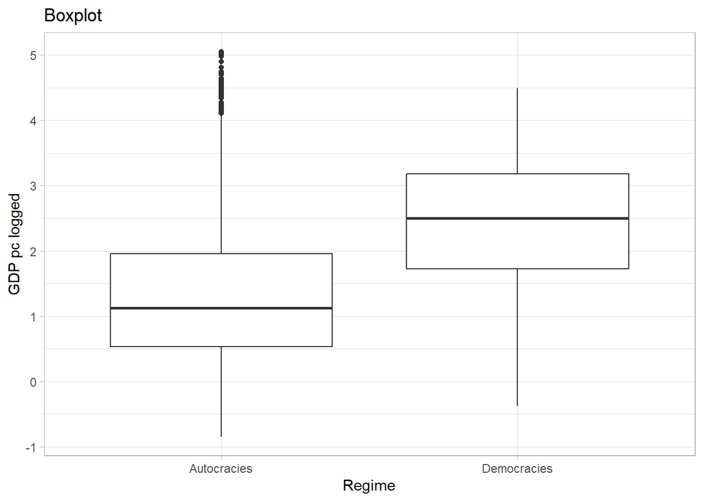

```r
vdem_coup %>%
      filter(!is.na(e_p_polity) & e_p_polity != "-88" & e_p_polity != "-77" & e_p_polity != "-66") %>%
      mutate(Regime = case_when(e_p_polity <= 5 ~ 'Autocracies', e_p_polity > 5 ~ 'Democracies')) %>%
      ggplot(aes(x = Regime, y = log(e_gdppc))) +
      geom_boxplot() +
      labs(title = "Boxplot",
           x = "Regime",
           y = "GDP pc logged") +
      theme_light()
```

7. **Faceting**:
   - Use faceting to create multiple subplots (facets) based on one or more categorical variables.
   - Functions like **`facet_grid()`** and **`facet_wrap()`** help you create faceted plots

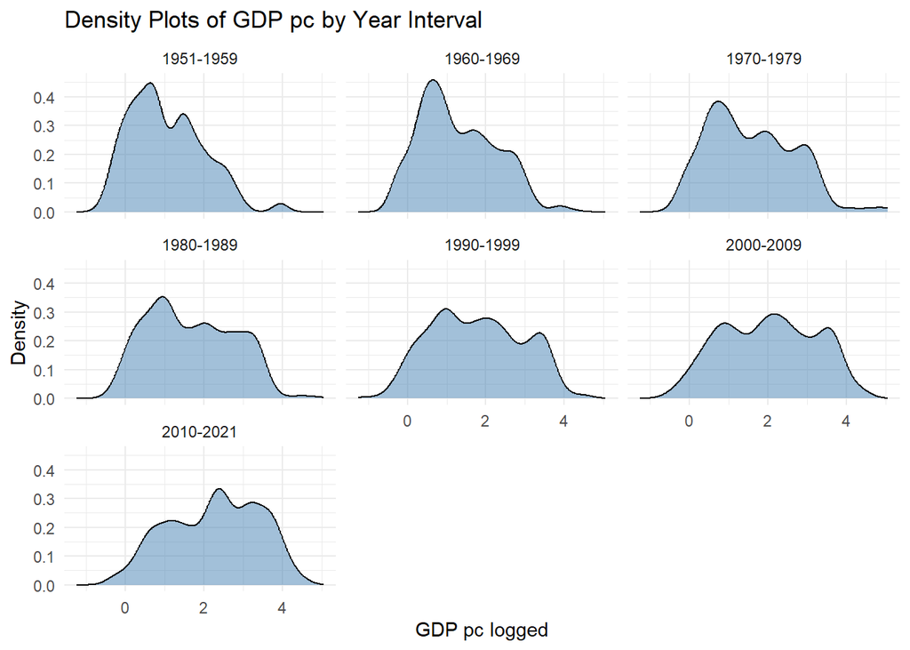

```r
# Define the year intervals for facets
year_intervals <- c("1951-1959", "1960-1969", "1970-1979", "1980-1989", "1990-1999", "2000-2009", "2010-2021")

# Create a new variable for year intervals
vdem_coup_new <- vdem_coup %>%
      mutate(YearInterval = cut(year, breaks = c(1950, 1960, 1970, 1980, 1990, 2000, 2010, 2022), # use mutate() to create a new variable YearInterval that categorizes years into the specified intervals using the cut() function
        labels = year_intervals, include.lowest = TRUE))

# Create density plots with facets
ggplot(vdem_coup_new, aes(x = log(e_gdppc))) +
      geom_density(fill = "steelblue", alpha = 0.5) +
      facet_wrap(~YearInterval) +
      labs(title = "Density Plots of GDP pc by Year Interval",
           x = "GDP pc logged",
           y = "Density") +
      theme_minimal()
```

8. **Legends**:
   - By default, ggplot2 creates legends for mapped aesthetics, such as colors, shapes, and sizes.
   - Customize legends using functions like **`scale_color_manual()`** and **`guides()`**.

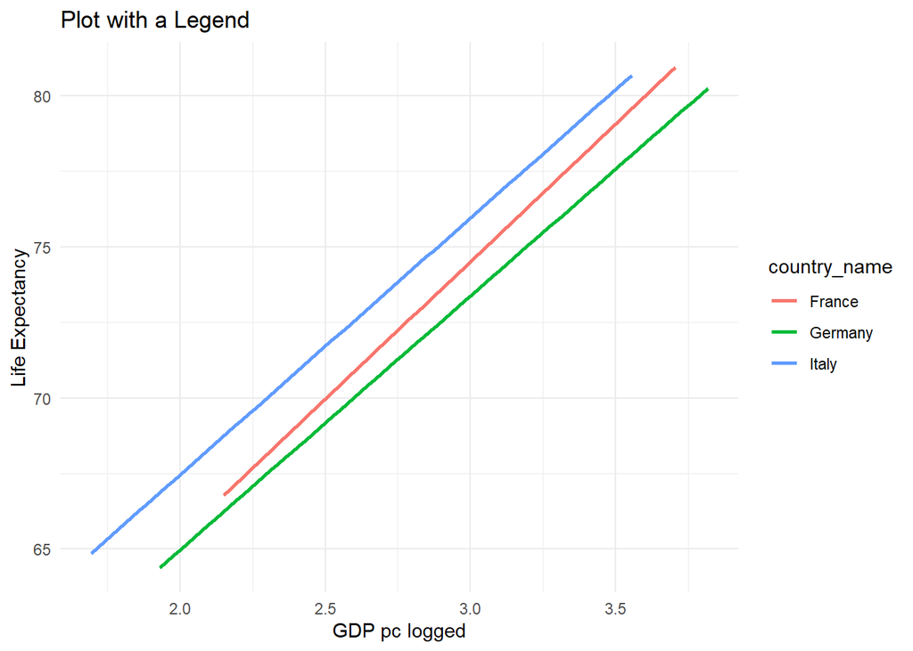

```r
# scatterplot with a legent but without customization

vdem_coup %>%
      filter(country_name %in% c("Germany", "Italy", "France")) %>%
      ggplot(aes(x = log(e_gdppc), y = e_pelifeex, color = country_name)) +
      stat_smooth(method = "lm", formula = y ~ x, se = FALSE) +  # Add linear regression lines
      labs(
        title = "Plot with a Legend",
        x = "GDP pc logged",
        y = "Life Expectancy"
      )+
      theme_minimal()
```

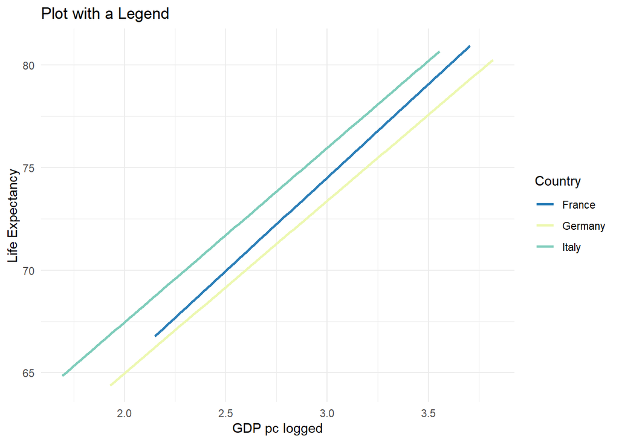

```r
# Customize legend
vdem_coup_new %>%
      filter(country_name %in% c("Germany", "Italy", "France")) %>%
      ggplot(aes(x = log(e_gdppc), y = e_pelifeex, color = country_name)) +
      stat_smooth(method = "lm", formula = y ~ x, se = FALSE) +  # Add linear regression lines
      labs(
        title = "Plot with a Legend",
        x = "GDP pc logged",
        y = "Life Expectancy"
      ) +
      scale_color_manual(values = c("Germany" = "#edf8b1", "Italy" = "#7fcdbb", "France" = "#2c7fb8"), # codes from https://colorbrewer2.org/#type=sequential&scheme=BuGn&n=3
                         name = "Country") +
      guides(color = guide_legend(title = "Country")) +
      theme_minimal()
```

## Plotting panel data

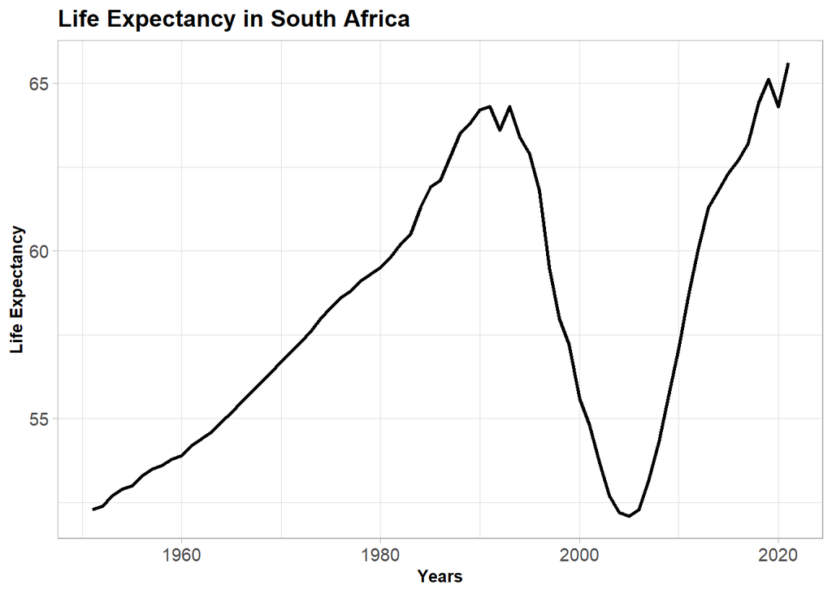

```r
# Simple line plot
vdem_coup %>%
    filter(country_name == "South Africa") %>%
  ggplot(aes(x = year, y = e_pelifeex)) +
    geom_line(size = 1) +
    labs(
      title = "Life Expectancy in South Africa",
      x = "Years",
      y = "Life Expectancy"
    ) +
    theme_light() +
    theme(
      title = element_text(size = 12, face = 'bold'),
      axis.text = element_text(size = 11),
      axis.title = element_text(size = 10)
    )
```

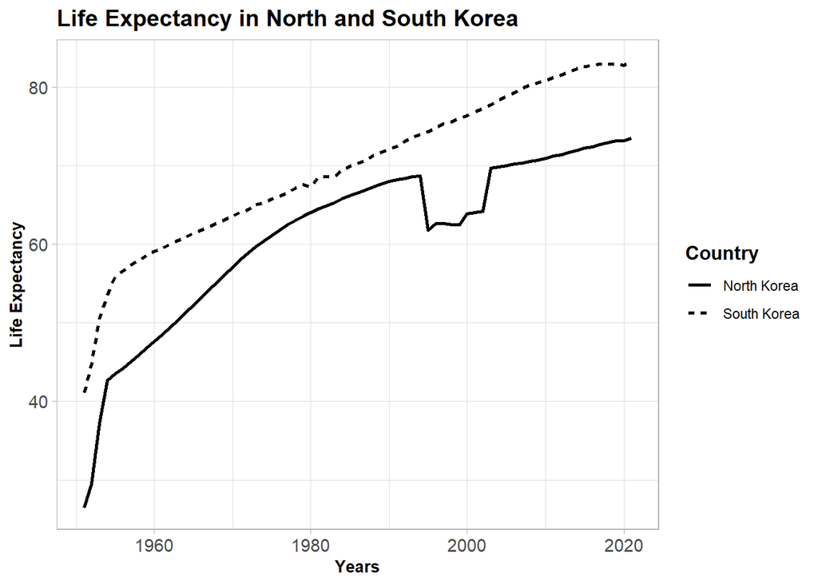

```r
# Line plot with grouping

vdem_coup %>%
  filter(country_name %in% c("North Korea", "South Korea")) %>%
  ggplot(aes(x = year, y = e_pelifeex, group = factor(country_name))) +
    geom_line(aes(linetype = country_name), size = 1) +
    labs(
      title = "Life Expectancy in North and South Korea",
      x = "Years",
      y = "Life Expectancy",
      linetype = "Country" # legend title
    ) +
    theme_light() +
    theme(
      title = element_text(size = 12, face = 'bold'),
      axis.text = element_text(size = 11),
      axis.title = element_text(size = 10)
    )
```

#### *Exercise: create a line plot showing how the proportion of countries with elected regional governments and different types of political regimes has changed since 1975*

- select following variables: **year, e_p_polity, country_name, v2elsrgel**
- filter the data by year and exclude unnecessary values by variable ‘e_p_polity’ (!= c(-88, -77, -66))
- create a new variable ‘Regime’ where ‘Democracies’ are from 6 to 10 including, and ‘Autocracies’ vary from -10 to 5 including
- do not forget about *group_by* argument!
- create a new variable ‘share’, i.e. share of countries with elected regional governments (values ‘2’ and ‘5’ of the variable **v2elsrgel**) from the number of all countries in general. TIP: “new variable” = n_distinct(country_name[old variable == c(…)]) / n_distinct(country_name))
- now you have everything for creating your plot!

[figure not shown]

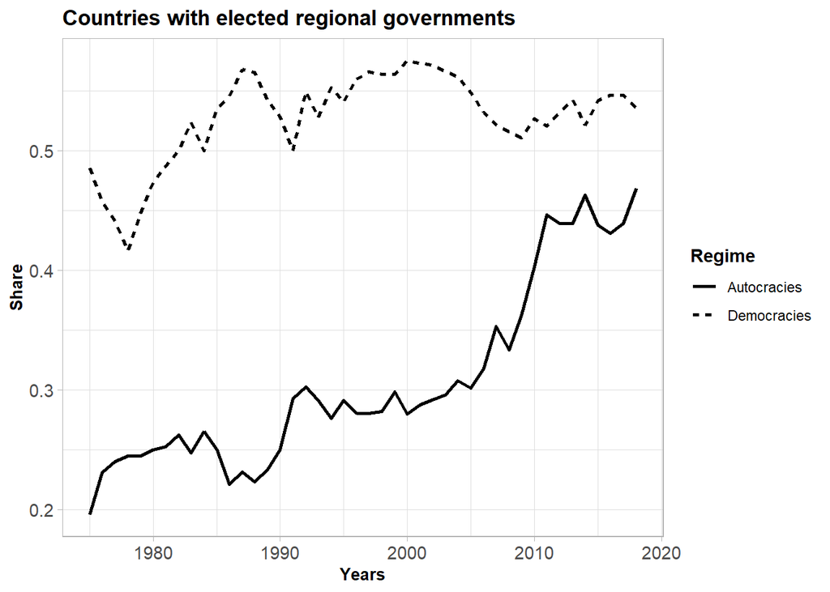

```r
vdem_coup %>%
  select(year, e_p_polity, country_name, v2elsrgel) %>%
  filter(year >= 1975, !e_p_polity %in% c(-88, -77, -66), !is.na(e_p_polity)) %>%
  mutate(Regime = case_when(e_p_polity <= 5 ~ 'Autocracies', e_p_polity > 5 ~ 'Democracies')) %>%
  group_by(year, Regime) %>%
  mutate(
    Share = sum(v2elsrgel %in% c("2", "5")) / n_distinct(country_name)
  ) %>%
  select(year, Share, Regime, country_name) %>%
  ggplot(aes(x = year, y = Share, group = Regime)) +
  geom_line(aes(linetype = Regime), lwd = 1) +
  labs(title = "Countries with elected regional governments") +
  xlab("Years") +
  ylab("Share") +
  theme_light() +
  theme(
    title = element_text(size = 11, face = 'bold'),
    axis.text = element_text(size = 11),
    axis.title = element_text(size = 10),
    legend.position = "right"
  )
```

## **Saving and Exporting**

- Save your ggplot2 plots as image files (e.g., PNG, PDF) or interactive web graphics (e.g., HTML) using functions like **`ggsave()`**.

```r
lineplot <- ggplot(vdem_coup_new, aes(x = log(e_gdppc))) +
  geom_density(fill = "steelblue", alpha = 0.5) +
  facet_wrap(~YearInterval) +
  labs(title = "Density Plots of GDP pc by Year Interval",
       x = "GDP pc logged",
       y = "Density") +
  theme_minimal()
```

- Save via ‘Export’ in the Utilities window